# QM 2022 Week 2: Probability and the Central Limit Theorem

Oliver Rittmann Domantas Undzėnas Lion Behrens

September 14 | 15 | 16, 2022

## Today we will learn

0. How to work with **RMarkdown**.
1. How to look at **Probability Distributions in R**.
   1. Discrete Probability Distributions.
   2. Continuous Probability Distributions.
2. What the **Central Limit Theorem** is.

## RMarkdown revisited

You have already started getting yourself acquainted with `R Markdown` while working on first assignment in `R Markdown`. Now it’s time to learn a bit more about it.

When you click the **Knit** or **Preview** button a document will be generated that includes both content as well as the output of any embedded R code chunks within the document. An R code chunk is anything that goes between `` ```{r} ... ``` ``. Additionally, you can name code chunks like this: `` ```{r name-here} ... ``` ``.

You can embed an R code chunk by typing it out or with a shortcut in RStudio (Mac: `Cmd+Alt+I`, Windows/Linux: `Ctrl+Alt+I`).

Here is a code chunk for you:

```r
# The first line sets an option for the final document that can be produced from
# the .Rmd file. Don't worry about it.
knitr::opts_chunk$set(
  echo = TRUE, # show results
  collapse = TRUE # not interrupt chunks
)

# The next bit (lines 56-75) is quite powerful and useful.
# First you define which packages you need for your analysis and assign it to
# the p_needed object.
p_needed <-
  c("viridis","ggplot2")

# Now you check which packages are already installed on your computer.
# The function installed.packages() returns a vector with all the installed
# packages.
packages <- rownames(installed.packages())
# Then you check which of the packages you need are not installed on your
# computer yet. Essentially you compare the vector p_needed with the vector
# packages. The result of this comparison is assigned to p_to_install.
p_to_install <- p_needed[!(p_needed %in% packages)]
# If at least one element is in p_to_install you then install those missing
# packages.
if (length(p_to_install) > 0) {
  install.packages(p_to_install)
}
# Now that all packages are installed on the computer, you can load them for
# this project. Additionally the expression returns whether the packages were
# successfully loaded.
sapply(p_needed, require, character.only = TRUE)
```

### Chunk Options

Chunk output in your final document can be customized with knitr options, arguments set in the `{}` of a chunk header. Here are some useful arguments:

- `include = FALSE` prevents code and results from appearing in the finished file. R Markdown still runs the code in the chunk, and the results can be used by other chunks.
- `echo = FALSE` prevents code, but not the results from appearing in the finished file. This is a useful way to embed figures.
- `message = FALSE` prevents messages that are generated by code from appearing in the finished file.
- `warning = FALSE` prevents warnings that are generated by code from appearing in the finished.
- `fig.cap = "..."` adds a caption to graphical results.

See the [R Markdown Reference Guide](https://rstudio.com/wp-content/uploads/2015/03/rmarkdown-reference.pdf?_ga=2.169319849.94966807.1602002830-1180689241.1600075670) for a complete list of knitr chunk options.

### Text formatting options

Markdown also provides an easy way to format the text in your document. Here are some basics:

- *This text is italic*
- **This text is bold**
- `This is code`
- [This is a link to the R Markdown homepage](https://rmarkdown.rstudio.com)

For more formatting options, we recommend the [R Markdown Cheat Sheet](https://raw.githubusercontent.com/rstudio/cheatsheets/master/rmarkdown.pdf).

## Probability Distributions

All common probability functions are defined in R already. To call them you have to combine a prefix and the distribution name.

The prefixes you can use are d, p, q and r. When to use which prefix?

1. Use **d** when you know x and want to know the density at that point.
   - The result is a point of the probability mass/density function.
   - If you put in a range of x values you will get the **PDF/PMF** of the distribution.
2. Use **p** when you know q and want to know the probability up to that point.
   - The result is a point on the cumulative distribution function or the area under the probability density function.
   - If you put in a range of values you will get the **CDF** of the distribution.
3. Use **q** when you know the area p and want to know the x value
   - This is exactly the opposite to p.
4. Use **r** if you want random numbers drawn from a distribution.
   - The result is a sample from a distribution.
5. The distribution names are:
   - `binom` for the Binomial distribution
   - `norm` for the Normal distribution
   - `unif` for the Uniform distribution

For each of the distributions you need to specify different parameters!

### Discrete Probability Distributions

Let’s start with Discrete Probability Distributions. Can you think of examples of Discrete Probability Distributions?

- Coin flip (multiple times)
- Number of votes obtained
- Number of members in a household
- Gender of a random person

#### The Bernoulli Distribution

The Bernoulli distribution is the simplest Discrete Probability Distribution. The Bernoulli distribution is a special case of the binomial distribution. It is a Binomial distribution with size 1. Thus, it is ideal for modelling **one-time** yes/no (success/failure) events.

```r
dbinom(x = 1, size = 1, prob = 0.8)  # What does the result tell us?

dbinom(x = 0, size = 1, prob = 0.8)  # What does the result tell us?
```

- `x` = number of successes (e.g. pass an exam)
- `size` = number of trials (1 coin flip)
- `prop` = probability of ‘success’ (e.g. probability of passing an exam)

The best example is **one** coin flip (or one voter voting yes/no, a person being either a woman/man). Let’s simulate one simple coin toss:

```r
rbinom(n = 1, size = 1, prob = 0.5)
```

Ok, we could have done this with a real coin. Let’s toss one coin 1000 times. Any volunteers?

Luckily, R can simulate this quicker.

```r
trial1 <- rbinom(n = 1000, size = 1, prob = 0.5)
```

- `n` = number of observations (i.e. how many coin flips we want to observe)

And now we want to see how successful we were:

```r
table(trial1)
```

#### The Binominal Distribution

We get a binomial distribution if we – like in the lecture example – toss a coin twice. What are the possible outcomes, the so-called sample space?

- **Sample space**: {HH, HT, TH, TT}
- What is the probability of observing exactly 0 (1, 2) heads (successes)?

```r
dbinom(x = c(0, 1, 2),
       size = 2,
       prob = 0.5)
```

- What is the probability of observing 0 or 1 heads (successes)?

```r
pbinom(1, 2, 0.5)
```

- What is the probability of more than 1 heads (successes)?

```r
1 - pbinom(1, 2, 0.5)

# or:

pbinom(1, 2, 0.5, lower.tail = F)
```

#### Example I: Coin Flips

We talked about probability in a frequentist understanding. Let’s check if repeating this experiment 1,000 times gives us the values we would expect.

Out of 1000 flips, you would expect 250 HH, 500 HT TH, and 250 TT.

```r
ex_trial <- rbinom(n = 1000, size = 2, prob = 0.5)
table(ex_trial)
```

#### The PMF and CDF of a Binomial

Let’s plot the binomial probability mass function to get a better understanding.

##### Base R

We start by creating an x-axis and an empty plot.

```r
# First, we need an x-axis
x_values <- 0:100

# Now we produce an empty plot.
plot(
  x = x_values,
  ylim = c(0, 0.1), # With ylim you can adjust the limits of the y axis.
  type = "n",       # type "n" produces an empty plot window.
  main = "PMF for Binomial (n = 100, p = 0.5)",
  xlab = "x",
  ylab = "p(x)",
  las = 1,
  frame = F
  )

# Let's add the points.
points(x_values,
       dbinom(x_values, size = 100, p = 0.5),
       cex = 0.3,
       pch = 19,
       col = viridis(1)
       )
```

[figure not shown]

```r
# And those lines we know from the lecture.
segments(x0 = x_values,
         y0 = 0,
         x1 = x_values,
         y1 = dbinom(x_values, size = 100, p = 0.5),
         col = viridis(1)
         )
```

> **Question: Why should we not use a line to connect the points?**

$\Rightarrow$ … because the outcome space is discrete, i.e. there is nothing like 2.5 heads out of a given number of coin flips.

What does the cumulative distribution function of the same Binomial look like?

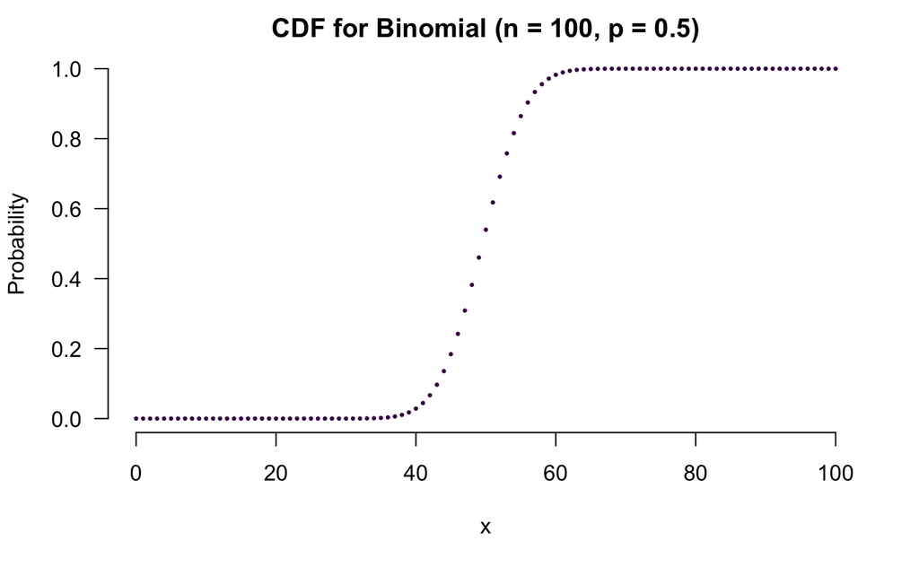

```r
plot(x = x_values,
     y = pbinom(x_values, size = 100, p = 0.5),
     type = "p",
     main = "CDF for Binomial (n = 100, p = 0.5)",
     xlab = "x",
     ylab = "Probability",
     bty = "n",
     las = 1,
     pch = 19,
     cex = 0.3,
     col = viridis(1),
     frame = F
     )
```

##### ggplot2

`ggplot2` is a very widely used package for visualization in R community. We will be providing you with code using this package in addition to the code with bulit-in functions of R.

First, a few words about `ggplot2`. When working with this package, we think about images as being constructed from layers: the *data*-level, the mapping *aesthetics* level, and the *geom* level. These are the essential, but there are many more:

- *Data:* your data frame
- *Aesthetic mapping:* how data (variables) become plot attributes (axes, color, sizes)
- *Geoms:* geometric representations of data (points, lines, bars)
- *Scales:* modifying the mapping from data to plot (customizing axes, colors, sizes)
- *Facets:* sub-panels in the plot
- *Coordinates:* features of the coordinate system (orientation…)

With `ggplot2`package, it is most effective to work with datasets. So we’ll start by putting all of our vectors into a `data.frame` object.

```r
library(ggplot2)

# create a dataset
binom_data <- data.frame(x = x_values,
                         density = dbinom(x_values, size = 100, p = 0.5))

# plot
ggplot( # empty plot for our data
  data = binom_data, # data used for plotting
  mapping = aes(x = x, y = density) # axes
) +
  geom_point(color = viridis(1)) + # add points
  geom_segment(aes( # add lines
    x = x, xend = x, # how thick the lines will be
    y = 0, yend = density # how long the lines will be
  ),
  color = viridis(1) # color the lines
  ) +
  theme_minimal() + # change the appearance
  labs(
    title = "PMF for Binomial (n = 100, p = 0.5)",
    y = "p(x)"
  )
```

> **Question: Why should we not use a line to connect the points?**

$\Rightarrow$ … because the outcome space is discrete, i.e. there is nothing like 2.5 heads out of a given number of coin flips.

What does the cumulative distribution function of the same Binomial look like?

```r
# Add new column to our dataset

binom_data$CDF <- pbinom(x_values, size = 100, p = 0.5)

ggplot(
  data = binom_data, # data used for plotting
  mapping = aes(x = x, y = CDF) # axes
) +
  geom_point(color = viridis(1)) + # add points
  theme_minimal() + # change the appearance
  labs(
    title = "CDF for Binomial (n = 100, p = 0.5)",
    y = "P(x)"
  )
```

#### Example II: Airline Reservations

A flight has 100 available seats, but the airline accepted 120 reservations (overbooking).

The probability of each person showing up is 0.85.

Now the airline wants to know the probability that more than 100 people show up.

- Remember the binomial process:
  - n independent trials
  - only two possible outcomes (show up/don’t show up)
  - success probability remains constant

We want to know:

$Pr(X>100)$.

This is $Pr(X=101)+Pr(X=102) +...Pr(X=120)$ (equal to $1-Pr(X\leq100)$.

1. What is the probability that more than 100 people show up?

```r
# Answer to a):
1 - pbinom(q = 100, size = 120, p = 0.85)
```

```
[1] 0.6586167
```

2. Plot the cumulative distribution function of the problem.

##### Base R

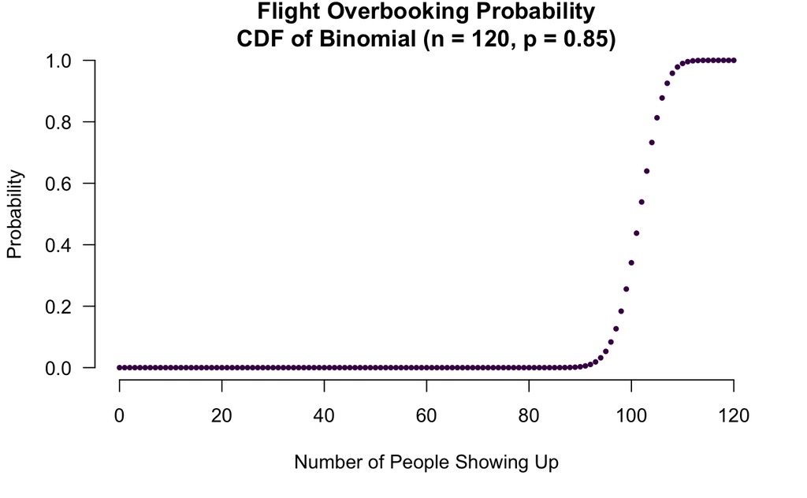

```r
# Answer to b):
passengers  <- 0:120 # for x-axis

plot(x = passengers,
     y = pbinom(q = passengers, size = 120, p = 0.85),
     bty = "n",
     las = 1,
     pch = 19,
     xlab = "Number of People Showing Up",
     ylab = "Probability",
     main = "Flight Overbooking Probability\nCDF of Binomial (n = 120, p = 0.85)",
     cex = 0.5,
     col = viridis(1),
     frame = F
     )
```

##### ggplot2

```r
# Answer to b):

# create a dataframe
airline_data <- data.frame(x = 0:120,
                           CDF = pbinom(q = 0:120, size = 120, p = 0.85))
# plot
ggplot(data = airline_data,  # data used for plotting
       mapping = aes(x = x, y = CDF)) +
  geom_point(color = viridis(1)) + # add points
  theme_minimal() + # change the appearance
  labs(x = "Number of People Showing Up",
       y = "Probability",
       title = "Flight Overbooking Probability\nCDF of Binomial (n = 120, p = 0.85)")
```

3. What is the probability of more than 100 people showing up if the airline limits overbooking to 110?

```r
# Answer to c):
1 - pbinom(q = 100, size = 110, p = 0.85)
```

### Continuous Probability Distributions

We will be often looking at normal distributions. The most common normal distribution is the standard normal distribution.

> **What do you know about the standard normal distribution?**

Let’s go through those prefixes for the normal distribution again. If you want to know the probability that $x < 1.96$, use $p$:

```r
pnorm(q = 1.96, mean = 0, sd = 1)
```

```
[1] 0.9750021
```

```r
1 - pnorm(q = 1.96, mean = 0, sd = 1)
```

```
[1] 0.0249979
```

If you want to know at what value of $x$ do 30% of the data lie, use $q$:

```r
qnorm(p = 0.3, mean = 0, sd = 1)
```

If you want to generate some random numbers of the normal distribution use $r$:

```r
rnorm(n = 20, mean = 0, sd = 1)
```

It is a good idea to plot those distributions (since `R` can draw better than me):

#### Base R

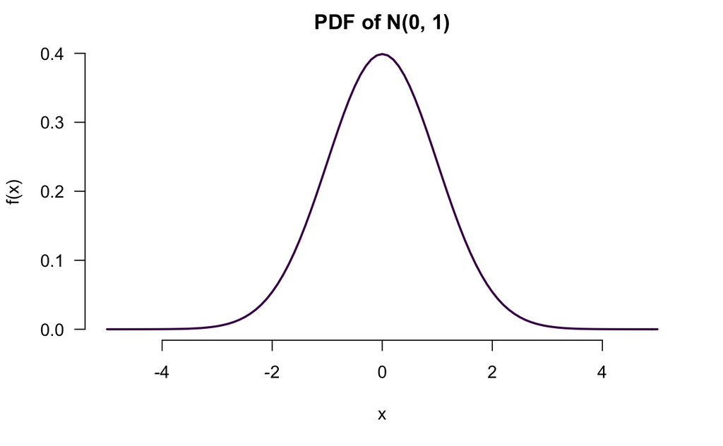

```r
x_values <- seq(from = -5, to = 5, by = 0.1)

plot(x = x_values,
     y = dnorm(x_values),
     bty = "n",
     las = 1,
     type = "l",
     col = viridis(1),
     lwd = 2,
     main = "PDF of N(0, 1)",
     ylab = "f(x)",
     xlab = "x"
     )
```

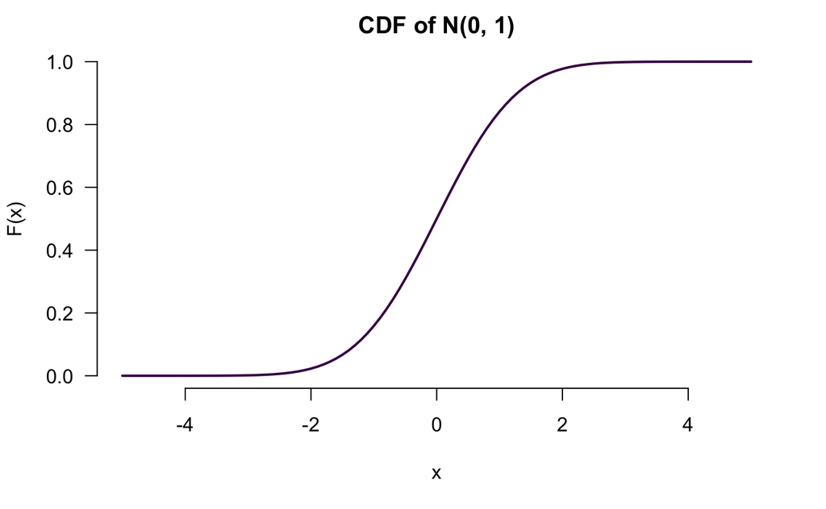

```r
plot(x = x_values,
     y = pnorm(x_values),
     bty = "n",
     las = 1,
     type = "l",
     col = viridis(1),
     lwd = 2,
     main = "CDF of N(0, 1)",
     ylab = "F(x)",
     xlab = "x"
     )
```

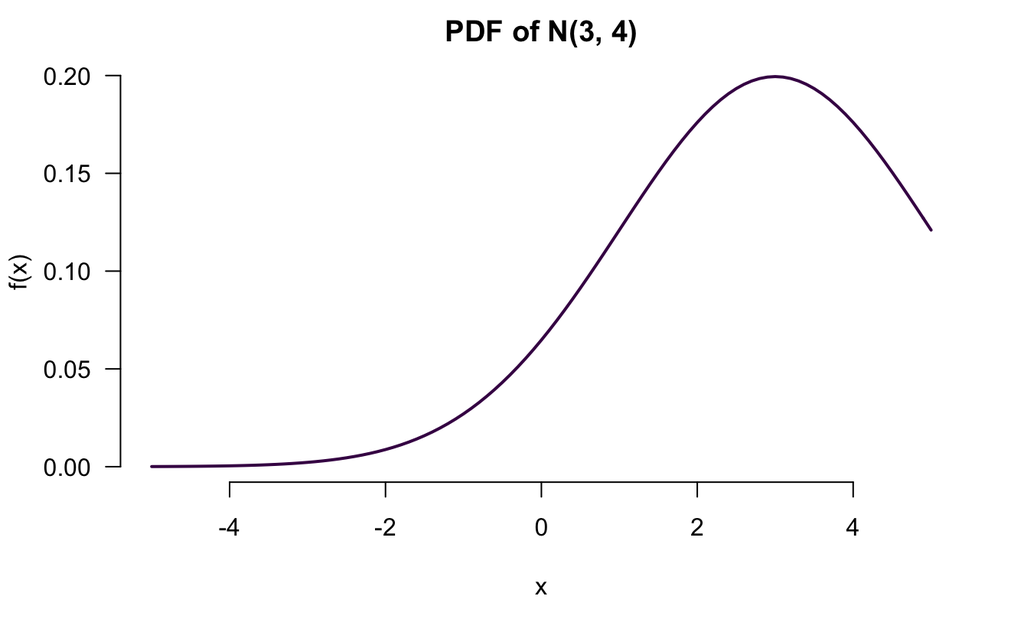

```r
# What if we have a different mean and sd?
plot(x = x_values,
     y = dnorm(x_values, mean = 3, sd = 2),
     bty = "n",
     las = 1,
     type = "l",
     col = viridis(1),
     lwd = 2,
     main = "PDF of N(3, 4)",
     ylab = "f(x)",
     xlab = "x"
     )
```

#### ggplot2

```r
x_values <- seq(from = -5, to = 5, by = 0.1)

# ggplot can also work without datasets

ggplot() + # this creates an empty plot
  geom_line(aes(x = x_values, y = dnorm(x_values)),
            color = viridis(1)) +
  labs(title = "PDF of N(0, 1)",
       y = "f(x)",
       x = "x") +
  theme_bw()

ggplot() + # this creates an empty plot
  geom_line(aes(x = x_values, y = pnorm(x_values)),
            color = viridis(1)) +
  labs(title = "CDF of N(0, 1)",
       y = "F(x)",
       x = "x") +
  theme_bw()

ggplot() + # this creates an empty plot
  geom_line(aes(x = x_values, y = dnorm(x_values, mean = 3, sd = 2)),
            color = viridis(1)) +
  labs(title = "PDF of N(3, 4)",
       y = "f(x)",
       x = "x") +
  theme_bw()
```

#### Example III: Normal Approximation of the Binomial

We saw that the binomial distribution can be approximated by the normal. Let’s calculate the airplane reservation example using a normal distribution.

First, we have to think about the underlying distribution. Using the central limit theorem, we can translate the binomial process into a normal distribution. 0.85 percent of the people are expected to show up, thus the mean can be calculated by $E(X)=n*p$. The variance can be calculated using $Var(X)=n*p*(1-p)$ (see slide 13).

Let’s calculate the mean and the variance of the normal distribution:

```r
n <- 120
p <- 0.85
mean <- n * p
sd <- sqrt((n * p * (1 - p)))  # Why do we have to use the square root?
```

Let’s solve an example with the normal distribution:

1. What is the probability that more than 100 people will show up, if we accept 120 reservations?
2. Plot the normal distribution.
3. Compare your result to the Binomial process from above.

##### Base R

```r
# part a)
1 - pnorm(q = 100, mean = mean, sd = sd)
```

```
[1] 0.695433
```

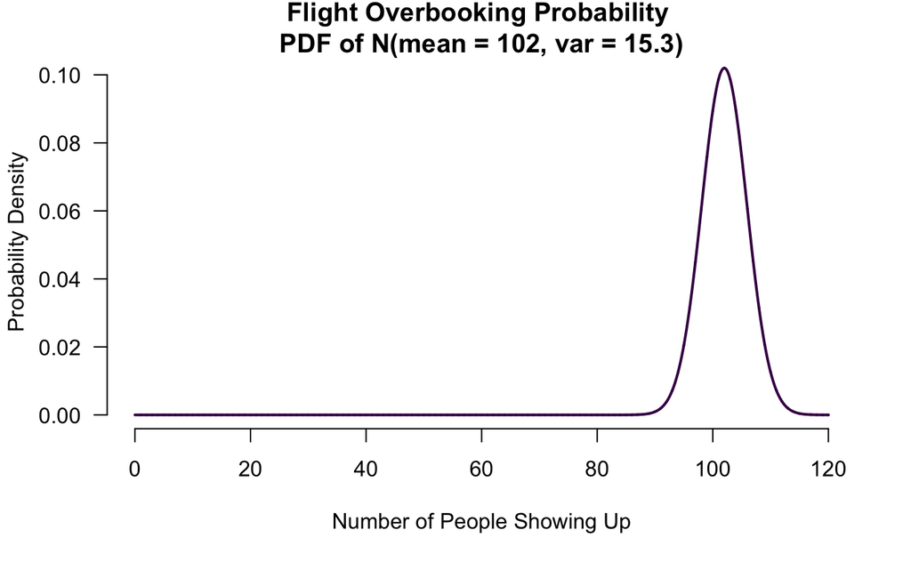

```r
# part b)
passengers <- seq(from = 0, to = 120, by = 0.01)
densities <- dnorm(passengers, mean = mean, sd = sd)

plot(
  x = passengers,
  y = densities,
  bty = "n",
  las = 1,
  col = viridis(1),
  xlab = "Number of People Showing Up",
  ylab = "Probability Density",
  type = "l",
  lwd = 2,
  cex = 2,
  main = "Flight Overbooking Probability \nPDF of N(mean = 102, var = 15.3)"
)
```

```r
# part c)
1 - pnorm(q = 100, mean = mean, sd = sd)
```

```
[1] 0.695433
```

```r
1 - pbinom(q = 100, size = n, prob = p)
```

```
[1] 0.6586167
```

##### ggplot2

```r
# part a)
1 - pnorm(q = 100, mean = mean, sd = sd)

# part b)
# modify dataset from before
airline_data$CDF_normal <- dnorm(airline_data$x, mean = mean, sd = sd)

ggplot(airline_data,
       aes(x = x,
           y = CDF_normal)) +
  geom_point(color = viridis(1)) +
  labs(
    title = "Flight Overbooking Probability \nPDF of N(mean = 102, var = 15.3)",
    x = "Number of People Showing Up",
    y = "Probability Density"
  )  +
  theme_bw()

# part c)
1 - pnorm(q = 100, mean = mean, sd = sd)
1 - pbinom(q = 100, size = n, prob = p)
```

## Central Limit Theorem

Finally, we want to better understand the central limit theorem. Let’s generate a random population:

```r
pop <- rnorm(1000, mean = 32, sd = 5) # we know the "true" values
summary(pop)
```

```
   Min. 1st Qu.  Median    Mean 3rd Qu.    Max.
  17.23   28.24   32.11   31.96   35.44   47.57
```

```r
var(pop)
```

```
[1] 25.79313
```

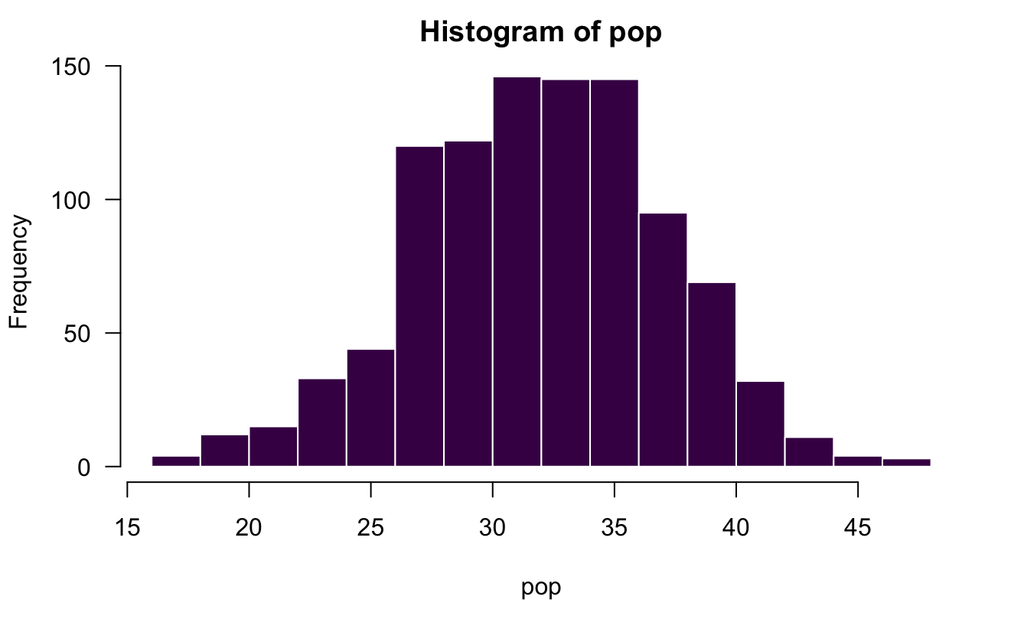

```r
hist(pop,
     bty = "n",
     las = 1,
     border = "white",
     col = viridis(1)
     )
```

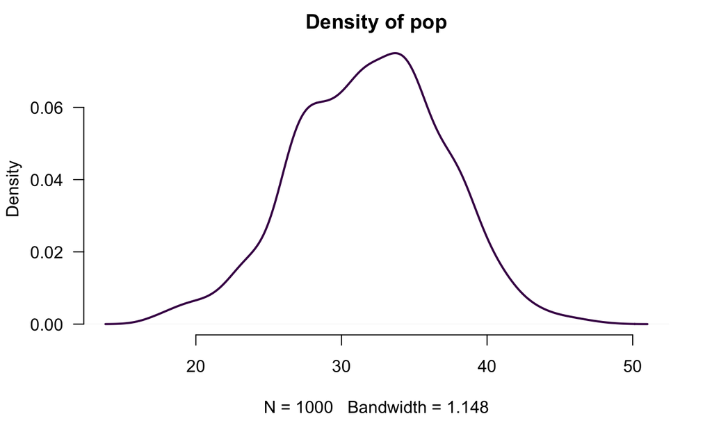

```r
plot(density(pop),
     bty = "n",
     las = 1,
     col = viridis(1),
     lwd = 2,
     main = "Density of pop"
     )
```

```r
sample(pop, 200) # take a random sample of size 200 from the population
```

```
  [1] 32.99182 30.77240 33.09463 38.78071 36.07493 28.30450 35.59584 24.91493 32.34317
 [10] 29.88080 30.81222 40.52588 30.91940 34.83530 32.61504 27.98595 36.66862 40.18577
 [19] 37.77281 36.62558 40.84072 35.15089 27.14619 36.45104 32.95554 21.74577 36.83237
 [28] 25.79149 26.35803 31.16667 34.73190 26.37899 39.44105 25.52984 29.14796 30.96159
 [37] 28.92476 34.57431 27.44536 31.75556 25.75138 30.03472 38.41411 33.92532 38.06208
 [46] 27.62494 31.35270 33.00971 36.30251 35.62596 41.11067 38.45256 41.50052 38.97245
 [55] 39.35758 29.84638 19.05025 22.13610 41.57303 26.61529 32.45003 29.63244 30.43863
 [64] 36.79369 28.53922 28.84470 21.44869 38.07880 39.51706 29.04685 34.26089 27.04536
 [73] 35.16437 37.77234 35.48962 32.62342 30.83033 28.88198 19.63528 31.75728 36.88420
 [82] 29.13618 37.41788 32.35333 32.42790 34.31910 30.63992 28.18805 36.24249 27.37979
 [91] 31.14612 31.36242 37.39798 26.65869 36.22033 34.37934 22.49663 23.35100 41.88205
[100] 40.80084 31.69940 27.61481 26.31941 33.87583 25.30113 32.28046 27.85704 33.39465
[109] 40.66764 35.62086 29.61930 42.80679 36.21797 30.55752 27.62543 23.45443 28.85349
[118] 28.24000 28.85712 38.86766 28.70954 28.99423 40.35198 40.01355 29.05137 31.30463
[127] 28.22729 31.08490 35.14946 28.25344 38.06602 36.18746 17.54478 28.40865 32.92078
[136] 34.87514 32.71806 27.48856 29.13335 43.86777 30.00630 33.82480 32.58015 28.78151
[145] 29.62974 34.34374 26.58033 23.40598 29.56016 27.34346 23.27750 30.43865 38.12096
[154] 28.52109 26.49126 33.78713 28.76373 35.29404 32.90159 32.24987 23.80347 33.93355
[163] 28.11373 27.71009 26.92156 40.56735 34.33820 33.06981 26.51684 21.06406 39.68866
[172] 35.10083 31.74293 24.93510 34.29473 24.77089 29.54855 28.99286 34.01746 27.24928
[181] 34.82831 37.99148 39.10660 24.25059 36.98838 30.11650 18.61649 35.61721 30.09917
[190] 28.11104 31.02468 38.10242 34.09698 27.71637 33.00374 27.72110 23.15893 33.84826
[199] 35.02541 30.99208
```

### CLT Trial 1: Sample Size = 100

Let’s take 100 samples with 100 persons in each sample. First, we create an empty vector - `trial1` - of length 100 to store the results:

```r
trial1 <- rep(NA, 100)
```

Now we have to do some programming. We create a *for loop* counting $i$ from 1 to 100. For each iteration the loop is saving the mean of our sample in the vector `trial1`.

```r
for (i in 1:100){
  trial1[i] <- mean(sample(pop, 100))
}

trial1
```

```
  [1] 32.07974 32.61697 32.01816 31.86484 31.75916 31.73658 31.74247 31.96759 31.29894
 [10] 31.72782 31.47939 32.02970 32.18415 31.55943 32.75527 32.30891 31.90794 31.99863
 [19] 31.82741 32.11387 32.50906 32.23357 32.16735 31.71279 32.02167 32.25039 32.65367
 [28] 32.55539 30.90010 32.13319 31.34850 31.87527 32.27156 31.20781 32.17464 30.88408
 [37] 31.79498 31.57218 32.50135 31.76091 32.00599 31.94649 31.72072 31.67538 32.01384
 [46] 32.04553 33.05503 32.02414 31.61242 31.01890 31.99967 32.30492 32.55018 31.82434
 [55] 31.32996 32.05155 31.55505 31.89215 32.02437 32.22624 31.76353 31.74978 32.04256
 [64] 31.51129 31.84120 32.17160 31.79980 31.76332 31.26992 33.25952 31.92287 31.49465
 [73] 30.83080 31.72271 31.86372 31.46955 32.15432 31.39908 31.92208 31.90379 32.20875
 [82] 32.01580 32.33108 31.31027 31.73876 32.38281 32.31116 32.81437 32.13995 31.78285
 [91] 31.70727 31.46929 30.84410 31.17043 32.00320 31.95264 32.24026 31.77058 32.23348
[100] 32.72169
```

Let’s have a look at our *sampling distribution*:

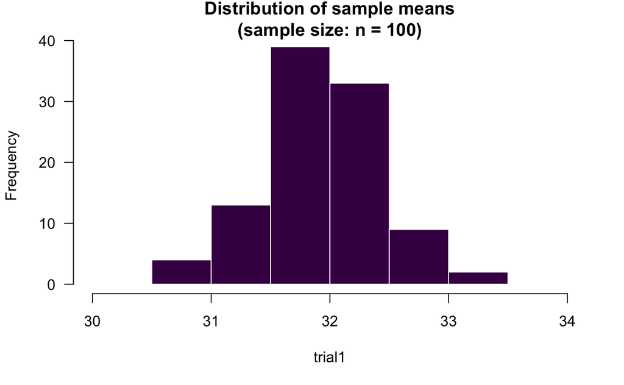

```r
hist(trial1,
     bty = "n",
     las = 1,
     border = "white",
     col = viridis(1),
     xlim = c(30, 34),
     main = "Distribution of sample means\n(sample size: n = 100)"
     )
```

```r
mean(trial1)
```

```
[1] 31.91387
```

```r
var(trial1)
```

```
[1] 0.2058794
```

### CLT Trial 2: Sample Size = 400

We do it again. But this time we will take 100 samples with 400 people in each sample. It works just as above.

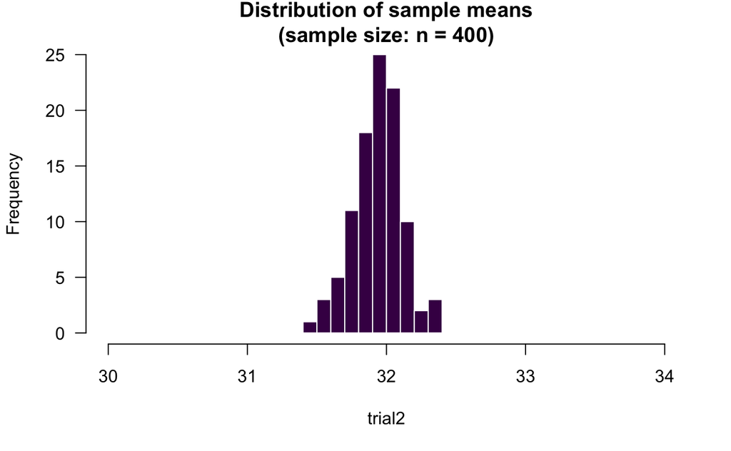

```r
trial2 <- rep(NA, 100)

for (i in 1:100){
  trial2[i] <- mean(sample(pop, 400))
}

hist(trial2,
     bty = "n",
     las = 1,
     border = "white",
     col = viridis(1),
     xlim = c(30, 34),
     main = "Distribution of sample means\n(sample size: n = 400)"
     )
```

```r
mean(trial2)
```

```
[1] 31.93691
```

```r
var(trial2)
```

```
[1] 0.03045397
```

Does the variance of the sampling distribution behave according to $\frac{sd^2}{n}$?

The original standard deviation value was 5, so $\frac{25}{n}$ should be the variance of our sampling distribution!

```r
var(pop)/400
```

```
[1] 0.06448284
```

In the lecture we learned that the sampling distribution of the mean always approaches a normal distribution, regardless of the shape of the original distribution!

You don’t believe me? See for yourself.

Income, for example, is usually not really normally distributed. First, we generate some hypothetical income data.

```r
income <- rgamma(1000, shape = 1.1, scale = 2000)
summary(income)
```

```
     Min.   1st Qu.    Median      Mean   3rd Qu.      Max.
    2.908   677.721  1492.148  2159.653  2993.209 21339.537
```

```r
var(income)
```

```
[1] 4509099
```

[figure not shown]

```r
# Let's have a look.
par(mfrow = c(1, 2)) # two plots side-by-side (alternative to chunk arguments)
hist(income,
     bty = "n",
     las = 1,
     border = "white",
     col = viridis(2)[1]
     )

plot(density(income),
     bty = "n",
     las = 1,
     col = viridis(2)[2],
     lwd = 2,
     main = "Density of income"
     )
```

This is clearly a non-normal distribution. Now we want to get our sampling distribution of the mean again.

### CLT Trial 3: A non-normal population distribution

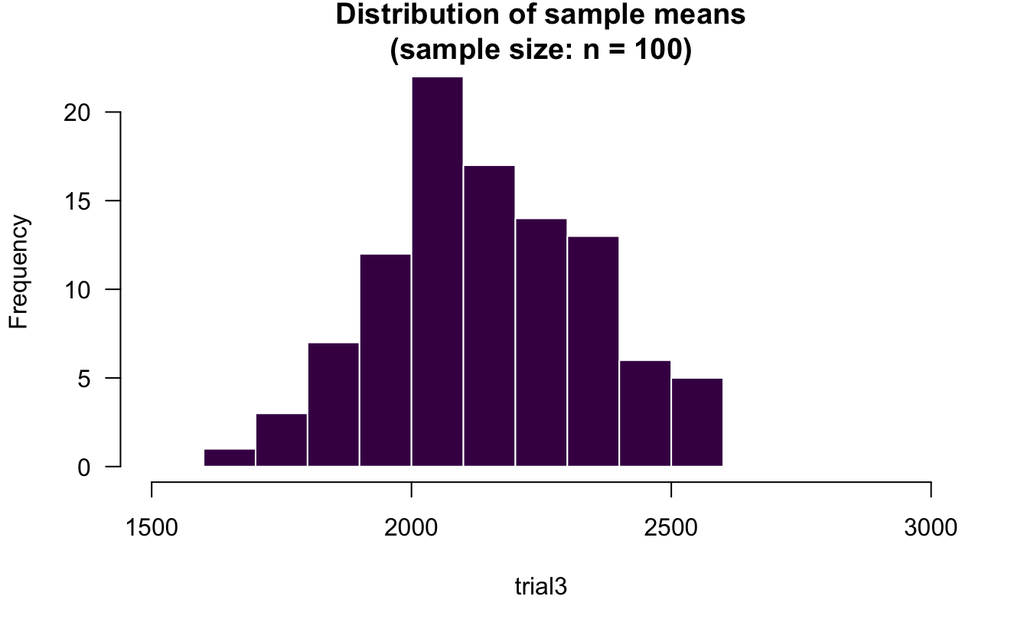

```r
trial3 <- rep(NA, 100)

for (i in 1:100){
  trial3[i] <- mean(sample(income, 100))
}

hist(trial3 ,
     bty = "n",
     las = 1,
     border = "white",
     col = viridis(1),
     xlim = c(1500, 3000),
     main = "Distribution of sample means\n(sample size: n = 100)"
     )
```

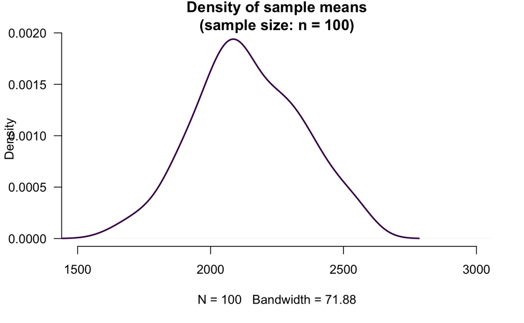

```r
plot(density(trial3),
     bty = "n",
     las = 1,
     lwd = 2,
     col = viridis(1),
     xlim = c(1500, 3000),
     main = "Density of sample means\n(sample size: n = 100)"
     )
```

```r
mean(trial3)
```

```
[1] 2141.741
```

```r
var(trial3)
```

```
[1] 40241.38
```

### CLT Trial 4: A non-normal population distribution II

#### Base R

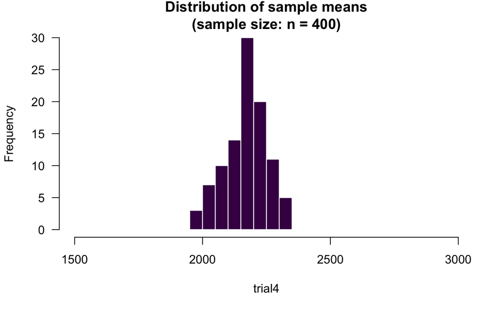

```r
trial4 <- rep(NA, 100)

for (i in 1:100){
  trial4[i] <- mean(sample(income, 400)) #this time, we sample 400 people
}

hist(trial4,
     bty = "n",
     las = 1,
     border = "white",
     col = viridis(1),
     xlim = c(1500, 3000),
     main = "Distribution of sample means\n(sample size: n = 400)"
     )
```

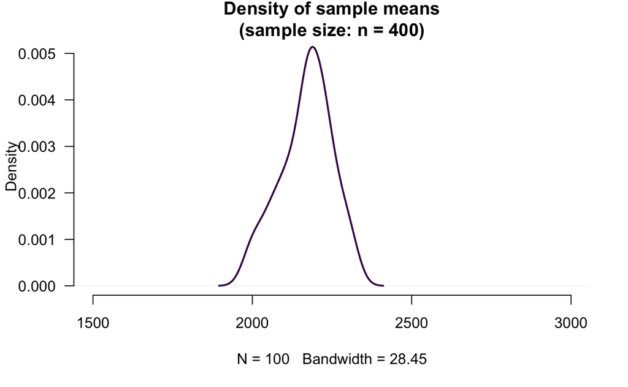

```r
plot(density(trial4),
     bty = "n",
     las = 1,
     lwd = 2,
     col = viridis(1),
     xlim = c(1500, 3000),
     main = "Density of sample means\n(sample size: n = 400)"
     )
```

```r
mean(trial4)
```

```
[1] 2168.888
```

```r
var(trial4)
```

```
[1] 6605.584
```

#### ggplot2

```r
trial4 <- rep(NA, 100)

for (i in 1:100){
  trial4[i] <- mean(sample(income, 400)) #this time, we sample 400 people
}

ggplot() +
  geom_histogram(aes(x = trial4),
                 boundary = 2200,
                 binwidth = 20,
                 color = "white",
                 fill = viridis(1)) +
  theme_bw() +
  labs(title = "Distribution of sample means\n(sample size: n = 400)")

ggplot() +
 geom_density(aes(trial4)) +
  labs(title = "Density of sample means\n(sample size: n = 400)",
       y = "F(x)",
       x = "x") +
  theme_bw()

mean(trial4)
var(trial4)
```

### Set Seeds!

Setting seeds is extremely helpful for the homework and replicability in general. To do so, use the following command: `set.seed()`.

```r
a <- rnorm(5)

b <- rnorm(5)

a == b


set.seed(1234)
a <- rnorm(5)

set.seed(1234)
b <- rnorm(5)

a == b
```

## Concluding remarks

Next, you find some exercises to check your knowledge.

## Exercises

### Exercise A: Airline reservations again

Now the airline also has a bigger plane.

The flight has 250 available seats, but the airline accepted 275 reservations (overbooking).

Since this is a long haul flight, the probability of each person showing up is a bit higher at 0.89.

Now the airline wants to know the probability that more than 250 people show up.

- Remember the binomial process:
  - n independent trials
  - only two possible outcomes (show up, don’t show up)
  - success probability remains constant

We want to know:

$Pr(X>250)$.

This is $Pr(X=251)+Pr(X=252) +...Pr(X=275)$ (equal to $1-Pr(X<=250)$.

1. What is the probability that more than 250 people show up?
2. Plot the cumulative distribution function of the problem.
3. What is the probability of more than 250 people showing up if the airline limits overbooking to 260?

```r
# Answer to a):

# Answer to b):
xaxis <-c(0:275) # for x-axis
plot(x = xaxis,
     y = # ??
     bty = "n",
     las = 1,
     pch = 19,
     xlab = "Number of people showing up",
     ylab = "Cumulative Distribution",
     main = "CDF of overbooking Binomial(n = 275, p = 0.89)",
     cex = 0.5,
     col = viridis(1),
     frame = F
     )

# Answer to c):
```

### Exercise B: Airline reservations and the Normal Approximation

We saw that the binomial distribution can be approximated by the normal. Let’s calculate the airplane reservation example using a normal distribution.

First, we have to think about the underlying distribution. Using the central limit theorem, we can translate the binomial process into a normal distribution. 0.89 percent of the people are expected to show up, thus the mean can be calculated by $E(X)=n*p$. The variance can be calculated using $Var(X)=n*p*(1-p)$ (see slide 13).

Let’s calculate the mean and the standard deviation of the normal distribution:

```r
# n <-
# p <-

# mean <-
# sd <-

# mean
# sd
```

Let’s solve an example with the normal distribution:

1. What is the probability that more than 250 people will show up, if we make 275 reservations?
2. Plot the normal distribution.
3. Compare your result to the Binomial process from above.

```r
# answer to a)

# answer to b)
xaxis <- seq(0, 275, 0.01)
plot(x = xaxis,
     y = # ??,
     bty = "n",
     las = 1,
     col = viridis(1),
     xlab = "% of People showing up",
     ylab = "Probability Density",
     type = "l",
     lwd = 2,
     cex = 2,
     main = "PDF of overbooking example N(244.75, 5.19)"
     )

# answer to c)
```